# FINAL PROJECT TWO

Data classification and prediction of breast cancer

URL LINK GITHUB: https://github.com/CB560/CB560Repository

```r
library(ggplot2)
library(dplyr)
library(knitr)
library(ggthemes)
library(gridExtra)
library(corrplot)
library(reshape)
library(caret)
library(caretEnsemble)
library(caTools)
library(data.table)
library(xgboost)
library(gbm)
library(kernlab)
library(C50)
library(glmnet)
library(magrittr)
```

```r
# Read the data
df <- read.csv("data.csv", stringsAsFactors = TRUE)

str(df)
```

```
## 'data.frame':    569 obs. of  33 variables:
##  $ id                     : int  842302 842517 84300903 84348301 84358402 843786 844359 84458202 844981 84501001 ...
##  $ diagnosis              : Factor w/ 2 levels "B","M": 2 2 2 2 2 2 2 2 2 2 ...
##  $ radius_mean            : num  18 20.6 19.7 11.4 20.3 ...
##  $ texture_mean           : num  10.4 17.8 21.2 20.4 14.3 ...
##  $ perimeter_mean         : num  122.8 132.9 130 77.6 135.1 ...
##  $ area_mean              : num  1001 1326 1203 386 1297 ...
##  $ smoothness_mean        : num  0.1184 0.0847 0.1096 0.1425 0.1003 ...
##  $ compactness_mean       : num  0.2776 0.0786 0.1599 0.2839 0.1328 ...
##  $ concavity_mean         : num  0.3001 0.0869 0.1974 0.2414 0.198 ...
##  $ concave.points_mean    : num  0.1471 0.0702 0.1279 0.1052 0.1043 ...
##  $ symmetry_mean          : num  0.242 0.181 0.207 0.26 0.181 ...
##  $ fractal_dimension_mean : num  0.0787 0.0567 0.06 0.0974 0.0588 ...
##  $ radius_se              : num  1.095 0.543 0.746 0.496 0.757 ...
##  $ texture_se             : num  0.905 0.734 0.787 1.156 0.781 ...
```

[output cut: 19 more lines]

```r
# Remove id and X columns since they are not useful and have no values
df$id <- NULL
df$X <- NULL
# Sort rows alphabetically and put target at the end
df <- df[, order(names(df))]
df <- df[, c(1:12, 14:31, 13)]
```

Data exploration

Looking at the data, there are more cases of benign than malignant breast mass, so upsampling could be useful for the models. Looking at the boxplots of the scaled data shows that most of the attributes are skewed upwards and have outliers in the upper tail, and the area and radius have less variation, especially compared to concavity and smoothness.

By looking at the plots, it shows that the variables split by malignant and benign reveal the two features of symmetry and fractal dimension are not useful at separating the classes. The features like area, concavity, and radius all separate the data better.

By plotting the correlation between the variables, it shows that there is a high correlation between some variables since there is the mean, standard error, and worst case of the values, which should all be correlated since they all measure the spread of the same attributes. Principal Component Analysis would be a good way to reduce complexity and deal with the highly correlated variables.

```r
# Show summary of data
summary(df)
```

```
##    area_mean         area_se          area_worst     compactness_mean
##  Min.   : 143.5   Min.   :  6.802   Min.   : 185.2   Min.   :0.01938
##  1st Qu.: 420.3   1st Qu.: 17.850   1st Qu.: 515.3   1st Qu.:0.06492
##  Median : 551.1   Median : 24.530   Median : 686.5   Median :0.09263
##  Mean   : 654.9   Mean   : 40.337   Mean   : 880.6   Mean   :0.10434
##  3rd Qu.: 782.7   3rd Qu.: 45.190   3rd Qu.:1084.0   3rd Qu.:0.13040
##  Max.   :2501.0   Max.   :542.200   Max.   :4254.0   Max.   :0.34540
##  compactness_se     compactness_worst concave.points_mean concave.points_se
##  Min.   :0.002252   Min.   :0.02729   Min.   :0.00000     Min.   :0.000000
##  1st Qu.:0.013080   1st Qu.:0.14720   1st Qu.:0.02031     1st Qu.:0.007638
##  Median :0.020450   Median :0.21190   Median :0.03350     Median :0.010930
##  Mean   :0.025478   Mean   :0.25427   Mean   :0.04892     Mean   :0.011796
##  3rd Qu.:0.032450   3rd Qu.:0.33910   3rd Qu.:0.07400     3rd Qu.:0.014710
##  Max.   :0.135400   Max.   :1.05800   Max.   :0.20120     Max.   :0.052790
##  concave.points_worst concavity_mean     concavity_se     concavity_worst
##  Min.   :0.00000      Min.   :0.00000   Min.   :0.00000   Min.   :0.0000
##  1st Qu.:0.06493      1st Qu.:0.02956   1st Qu.:0.01509   1st Qu.:0.1145
##  Median :0.09993      Median :0.06154   Median :0.02589   Median :0.2267
##  Mean   :0.11461      Mean   :0.08880   Mean   :0.03189   Mean   :0.2722
##  3rd Qu.:0.16140      3rd Qu.:0.13070   3rd Qu.:0.04205   3rd Qu.:0.3829
##  Max.   :0.29100      Max.   :0.42680   Max.   :0.39600   Max.   :1.2520
##  fractal_dimension_mean fractal_dimension_se fractal_dimension_worst
##  Min.   :0.04996        Min.   :0.0008948    Min.   :0.05504
##  1st Qu.:0.05770        1st Qu.:0.0022480    1st Qu.:0.07146
##  Median :0.06154        Median :0.0031870    Median :0.08004
##  Mean   :0.06280        Mean   :0.0037949    Mean   :0.08395
##  3rd Qu.:0.06612        3rd Qu.:0.0045580    3rd Qu.:0.09208
##  Max.   :0.09744        Max.   :0.0298400    Max.   :0.20750
##  perimeter_mean    perimeter_se    perimeter_worst   radius_mean
##  Min.   : 43.79   Min.   : 0.757   Min.   : 50.41   Min.   : 6.981
##  1st Qu.: 75.17   1st Qu.: 1.606   1st Qu.: 84.11   1st Qu.:11.700
##  Median : 86.24   Median : 2.287   Median : 97.66   Median :13.370
##  Mean   : 91.97   Mean   : 2.866   Mean   :107.26   Mean   :14.127
##  3rd Qu.:104.10   3rd Qu.: 3.357   3rd Qu.:125.40   3rd Qu.:15.780
##  Max.   :188.50   Max.   :21.980   Max.   :251.20   Max.   :28.110
##    radius_se       radius_worst   smoothness_mean   smoothness_se
##  Min.   :0.1115   Min.   : 7.93   Min.   :0.05263   Min.   :0.001713
##  1st Qu.:0.2324   1st Qu.:13.01   1st Qu.:0.08637   1st Qu.:0.005169
##  Median :0.3242   Median :14.97   Median :0.09587   Median :0.006380
##  Mean   :0.4052   Mean   :16.27   Mean   :0.09636   Mean   :0.007041
##  3rd Qu.:0.4789   3rd Qu.:18.79   3rd Qu.:0.10530   3rd Qu.:0.008146
##  Max.   :2.8730   Max.   :36.04   Max.   :0.16340   Max.   :0.031130
##  smoothness_worst  symmetry_mean     symmetry_se       symmetry_worst
##  Min.   :0.07117   Min.   :0.1060   Min.   :0.007882   Min.   :0.1565
##  1st Qu.:0.11660   1st Qu.:0.1619   1st Qu.:0.015160   1st Qu.:0.2504
##  Median :0.13130   Median :0.1792   Median :0.018730   Median :0.2822
##  Mean   :0.13237   Mean   :0.1812   Mean   :0.020542   Mean   :0.2901
##  3rd Qu.:0.14600   3rd Qu.:0.1957   3rd Qu.:0.023480   3rd Qu.:0.3179
##  Max.   :0.22260   Max.   :0.3040   Max.   :0.078950   Max.   :0.6638
##   texture_mean     texture_se     texture_worst   diagnosis
##  Min.   : 9.71   Min.   :0.3602   Min.   :12.02   B:357
##  1st Qu.:16.17   1st Qu.:0.8339   1st Qu.:21.08   M:212
##  Median :18.84   Median :1.1080   Median :25.41
##  Mean   :19.29   Mean   :1.2169   Mean   :25.68
##  3rd Qu.:21.80   3rd Qu.:1.4740   3rd Qu.:29.72
##  Max.   :39.28   Max.   :4.8850   Max.   :49.54
```

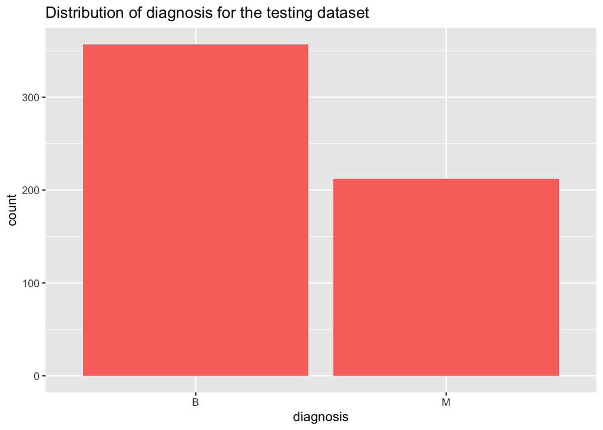

```r
ggplot(df, aes(x = diagnosis)) +
  geom_bar(aes(fill = 'pink')) +
  ggtitle("Distribution of diagnosis for the testing dataset") +
  theme(legend.position="none")
```

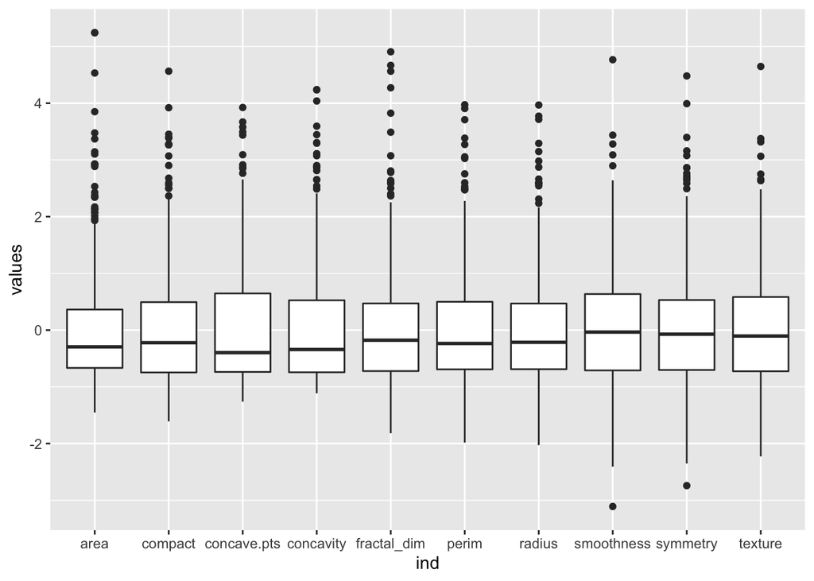

```r
# Boxplot of scaled values
df_box <- df[,c("area_mean", "compactness_mean", "concave.points_mean", "concavity_mean", "fractal_dimension_mean", "perimeter_mean", "radius_mean", "smoothness_mean", "symmetry_mean", "texture_mean")]
colnames(df_box) <- c("area", "compact", "concave.pts", "concavity", "fractal_dim", "perim", "radius", "smoothness", "symmetry", "texture")
ggplot(stack(data.frame(scale(df_box))), aes(x = ind, y = values)) +
  geom_boxplot()
```

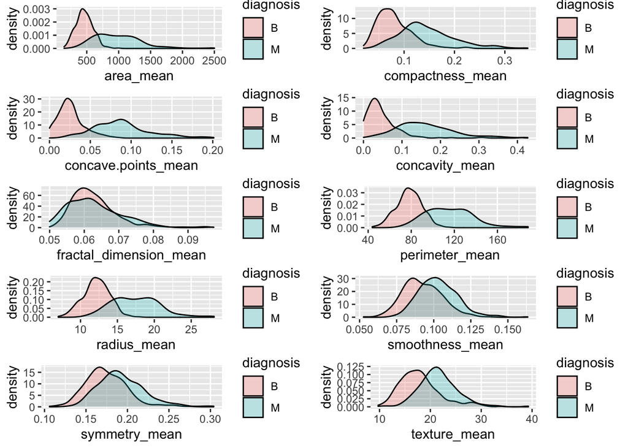

```r
# Plot differences between malignant and benign
g1 <- ggplot(df, aes(x=area_mean, fill=diagnosis)) + geom_density(alpha=0.25)
g2 <- ggplot(df, aes(x=compactness_mean, fill=diagnosis)) + geom_density(alpha=0.25)
g3 <- ggplot(df, aes(x=concave.points_mean, fill=diagnosis)) + geom_density(alpha=0.25)
g4 <- ggplot(df, aes(x=concavity_mean, fill=diagnosis)) + geom_density(alpha=0.25)
g5 <- ggplot(df, aes(x=fractal_dimension_mean, fill=diagnosis)) + geom_density(alpha=0.25)
g6 <- ggplot(df, aes(x=perimeter_mean, fill=diagnosis)) + geom_density(alpha=0.25)
g7 <- ggplot(df, aes(x=radius_mean, fill=diagnosis)) + geom_density(alpha=0.25)
g8 <- ggplot(df, aes(x=smoothness_mean, fill=diagnosis)) + geom_density(alpha=0.25)
g9 <- ggplot(df, aes(x=symmetry_mean, fill=diagnosis)) + geom_density(alpha=0.25)
g10 <- ggplot(df, aes(x=texture_mean, fill=diagnosis)) + geom_density(alpha=0.25)
grid.arrange(g1,g2,g3,g4,g5,g6,g7,g8,g9,g10, ncol=2)
```

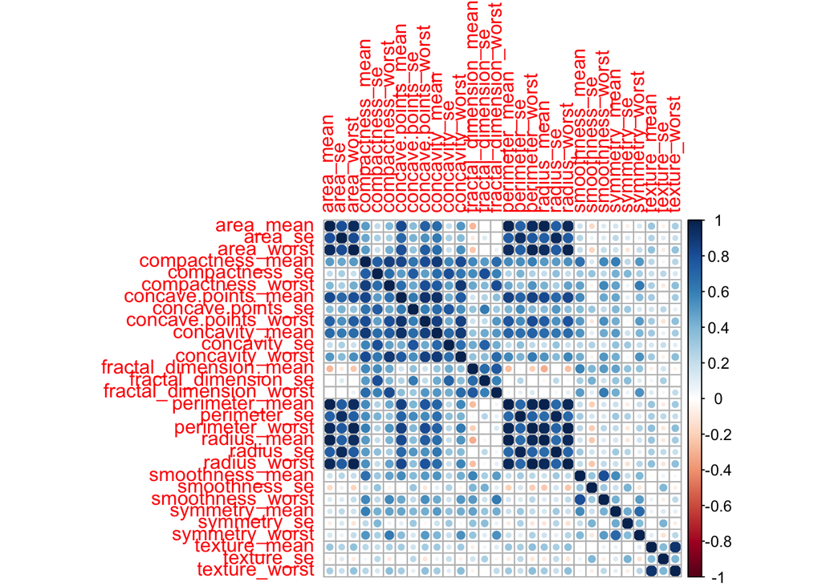

```r
# Plot correlation matrix to see al correlating values
corrplot(cor(df[,-31]), method="circle",)
```

METHOD

When building the models, malignant is assigned positive and benign is assigned negative.

Data is randomly split in a 70/30 train and test split.

12 different models are used with10-fold cross validation on the training data set. The individual models are then compared by their performance.

The 12 models:

Tree-Based Models: “C5.0”, “rf”, “rpart” Boosting Models: “xgbTree”, “xgbLinear”, “gbm” Clustering Models: “knn” Linear Models: “glm”, “glmnet” Non-linear Models: “nb”, “svmPoly”, “nnet”

Pre-processing methods for all twelve models:

There are less cases of malignant than benign so upsampling is used. The data was centered and scaled to make sure the algorithms are performed correctly. The use of nzv, rorr and pca is to handle all highly correlated variables in the data set as shown in the above correlation matrix.

ROC is optimized for these models to show a two-class summary report that shows sensitivity. Sensitivity is important because it has to do with cancer, an extremely small cell that is malignant can lead to the potential of the cancer spreading and then death. Maximizing recall over precision is very important.

MODEL PERFORMANCE:

The correlation between the models is compared and will be used for the stack ensemble approach.

Next compared the correlation between the models and decided not to remove any because the stacked ensemble model blends the strengths of each of these models as meta-models.

PREDICTIVE MODEL PREPARATION

```r
# Split data into train set and test set

index <- sample(1:nrow(df), 0.7 * nrow(df))
train <- df[index,]
test <- df[-index,]

# This makes sure that malignant is positive and benign is negative

df$diagnosis <- factor(df$diagnosis, levels = c("M", "B"))
train$diagnosis <- factor(train$diagnosis, levels = c("M", "B"))
test$diagnosis <- factor(test$diagnosis, levels = c("M", "B"))

# Compare distribution of train and test data

DistributionCompare <- cbind(prop.table(table(train$diagnosis)), prop.table(table(test$diagnosis)))
colnames(DistributionCompare) <- c("Train", "Test")
meltedDComp <- melt(DistributionCompare)
```

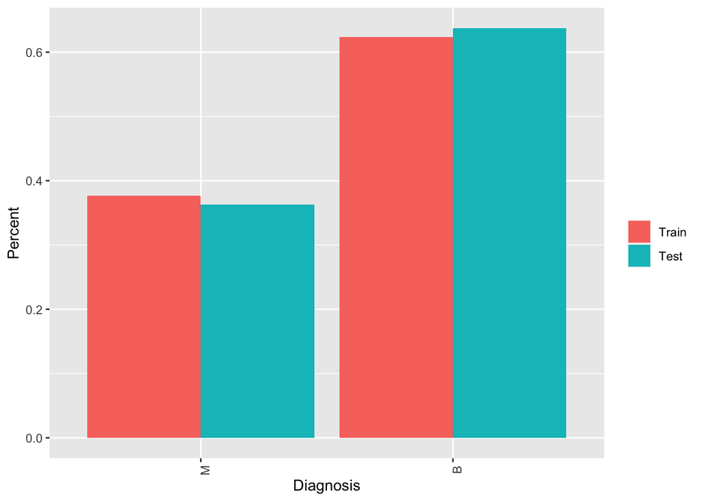

```r
ggplot(meltedDComp, aes(x=Var1, y=value)) + geom_bar(aes(fill=Var2), stat = "identity", position = "dodge") + theme(axis.text.x = element_text(angle = 90, hjust = 1)) + xlab("Diagnosis") + ylab("Percent") + labs(fill="")
```

TRAINING TWELVE MODELS 10-fold CV, center, scale, pca, upsampling and compare performance

```r
econtrol <- trainControl(method="cv", number=10, summaryFunction = twoClassSummary,
                         savePredictions = TRUE, classProbs = TRUE,  sampling = "up")
models <- caretList(diagnosis ~., data=train,
                    methodList=c("svmPoly", "nnet", "gbm", "xgbTree", "knn", "glm", "rf", "C5.0",
                                 "nb", "rpart", "xgbLinear", "glmnet"),
                    preProcess = c("center", "scale", "nzv","corr", "pca"),
                    trControl = econtrol,
                    metric = "ROC")
```

[output not shown]

RESULTS FOR ALL 12 MODELS

```r
results <- resamples(models)
summary(results)
```

```
##
## Call:
## summary.resamples(object = results)
##
## Models: svmPoly, nnet, gbm, xgbTree, knn, glm, rf, C5.0, nb, rpart, xgbLinear, glmnet
## Number of resamples: 10
##
## ROC
##                Min.   1st Qu.    Median      Mean   3rd Qu.      Max. NA's
## svmPoly   0.9546667 0.9953056 1.0000000 0.9941222 1.0000000 1.0000000    0
## nnet      0.9600000 0.9906111 0.9986667 0.9930000 1.0000000 1.0000000    0
## gbm       0.9520000 0.9953056 0.9972778 0.9922444 0.9973333 1.0000000    0
## xgbTree   0.9680000 0.9896667 1.0000000 0.9935556 1.0000000 1.0000000    0
## knn       0.9520000 0.9880000 0.9940000 0.9895278 0.9980000 1.0000000    0
## glm       0.9388889 0.9913056 0.9973333 0.9882778 0.9993333 1.0000000    0
## rf        0.9520000 0.9875833 0.9946667 0.9876667 0.9973056 1.0000000    0
## C5.0      0.9733333 0.9866667 0.9946667 0.9919444 0.9993333 1.0000000    0
## nb        0.9546667 0.9553333 0.9660556 0.9718778 0.9886667 1.0000000    0
## rpart     0.8722222 0.9356667 0.9566667 0.9458167 0.9693333 0.9819444    0
## xgbLinear 0.9760000 0.9825278 0.9946667 0.9908778 0.9993333 1.0000000    0
## glmnet    0.9626667 0.9926111 0.9973333 0.9935444 1.0000000 1.0000000    0
##
## Sens
##                Min.   1st Qu.    Median      Mean   3rd Qu. Max. NA's
## svmPoly   0.8666667 0.9333333 0.9333333 0.9533333 1.0000000    1    0
## nnet      0.9333333 0.9333333 0.9333333 0.9533333 0.9833333    1    0
## gbm       0.8000000 0.9333333 0.9666667 0.9533333 1.0000000    1    0
## xgbTree   0.8000000 0.9333333 0.9333333 0.9466667 1.0000000    1    0
## knn       0.9333333 0.9333333 0.9333333 0.9533333 0.9833333    1    0
## glm       0.9333333 0.9333333 0.9333333 0.9533333 0.9833333    1    0
## rf        0.8000000 0.9333333 0.9333333 0.9333333 0.9833333    1    0
## C5.0      0.8000000 0.8833333 0.9333333 0.9333333 1.0000000    1    0
## nb        0.7333333 0.8000000 0.8666667 0.8666667 0.9333333    1    0
## rpart     0.7333333 0.8166667 0.9333333 0.8866667 0.9333333    1    0
## xgbLinear 0.8666667 0.9333333 0.9666667 0.9600000 1.0000000    1    0
## glmnet    0.8666667 0.9333333 0.9333333 0.9533333 1.0000000    1    0
##
## Spec
##            Min.   1st Qu.    Median      Mean 3rd Qu. Max. NA's
## svmPoly   0.920 0.9587500 0.9800000 0.9718333    1.00 1.00    0
## nnet      0.920 0.9587500 0.9800000 0.9756667    1.00 1.00    0
## gbm       0.800 0.9295833 0.9591667 0.9476667    1.00 1.00    0
## xgbTree   0.880 0.9587500 0.9600000 0.9636667    0.99 1.00    0
## knn       0.920 0.9295833 0.9800000 0.9678333    1.00 1.00    0
## glm       0.875 0.9300000 0.9800000 0.9635000    1.00 1.00    0
## rf        0.880 0.9200000 0.9583333 0.9436667    0.96 1.00    0
## C5.0      0.840 0.9587500 0.9600000 0.9596667    0.99 1.00    0
## nb        0.880 0.9200000 0.9583333 0.9396667    0.96 0.96    0
## rpart     0.840 0.8900000 0.9591667 0.9313333    0.96 1.00    0
## xgbLinear 0.840 0.9583333 0.9600000 0.9556667    0.99 1.00    0
## glmnet    0.920 0.9700000 1.0000000 0.9838333    1.00 1.00    0
```

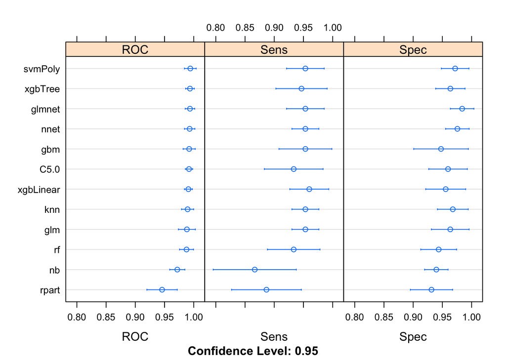

```r
dotplot(results)
```

MODEL CORRELATION

```r
mcr <-modelCor(results)
mcr
```

```
##               svmPoly       nnet         gbm     xgbTree        knn         glm
## svmPoly    1.00000000  0.9403644  0.98461622  0.89298663  0.9069585  0.35832320
## nnet       0.94036436  1.0000000  0.95217362  0.88922587  0.8587928  0.58153577
## gbm        0.98461622  0.9521736  1.00000000  0.90909191  0.9085563  0.36928339
## xgbTree    0.89298663  0.8892259  0.90909191  1.00000000  0.9440978  0.22126872
## knn        0.90695852  0.8587928  0.90855633  0.94409779  1.0000000  0.21710734
## glm        0.35832320  0.5815358  0.36928339  0.22126872  0.2171073  1.00000000
## rf         0.81449708  0.8389744  0.85813976  0.93293791  0.7899802  0.17969785
## C5.0       0.24595616  0.1953296  0.27499739  0.55880600  0.4753139 -0.24902306
## nb        -0.05130519 -0.2213864 -0.05060646 -0.07177463 -0.1483714 -0.62707401
## rpart      0.01094588  0.0169836 -0.01577774  0.16360423  0.2061568 -0.24493081
## xgbLinear  0.50761792  0.5346192  0.53827051  0.80466113  0.6428282 -0.07737551
## glmnet     0.95172180  0.9821549  0.96353952  0.88725868  0.8937774  0.52728511
##                   rf        C5.0          nb       rpart   xgbLinear
## svmPoly   0.81449708  0.24595616 -0.05130519  0.01094588  0.50761792
## nnet      0.83897438  0.19532958 -0.22138645  0.01698360  0.53461917
## gbm       0.85813976  0.27499739 -0.05060646 -0.01577774  0.53827051
## xgbTree   0.93293791  0.55880600 -0.07177463  0.16360423  0.80466113
## knn       0.78998018  0.47531389 -0.14837142  0.20615684  0.64282821
## glm       0.17969785 -0.24902306 -0.62707401 -0.24493081 -0.07737551
## rf        1.00000000  0.46719188  0.11226406  0.08732977  0.80403328
## C5.0      0.46719188  1.00000000 -0.10527724  0.08120474  0.78266665
## nb        0.11226406 -0.10527724  1.00000000 -0.06644633 -0.10556537
## rpart     0.08732977  0.08120474 -0.06644633  1.00000000  0.23986606
## xgbLinear 0.80403328  0.78266665 -0.10556537  0.23986606  1.00000000
## glmnet    0.82306204  0.18187762 -0.15469257 -0.02082582  0.48717804
##                glmnet
## svmPoly    0.95172180
## nnet       0.98215485
## gbm        0.96353952
## xgbTree    0.88725868
## knn        0.89377736
## glm        0.52728511
## rf         0.82306204
## C5.0       0.18187762
## nb        -0.15469257
## rpart     -0.02082582
## xgbLinear  0.48717804
## glmnet     1.00000000
```

[figure not shown]

```r
splom(results)
```

STACKED MODEL USING BOOSTED TREE MODEL ON META-MODELS

```r
stack <- caretStack(models, method="xgbTree", metric="Sens", verbose = FALSE,
                     trControl = trainControl(method="boot", number=15, savePredictions="final",
                                              classProbs=TRUE, summaryFunction=twoClassSummary)
)

summary(stack)
```

```
##               Length Class              Mode
## handle            1  xgb.Booster.handle externalptr
## raw           34382  -none-             raw
## niter             1  -none-             numeric
## call              6  -none-             call
## params            8  -none-             list
## callbacks         0  -none-             list
## feature_names    12  -none-             character
## nfeatures         1  -none-             numeric
## xNames           12  -none-             character
## problemType       1  -none-             character
## tuneValue         7  data.frame         list
## obsLevels         2  -none-             character
## param             1  -none-             list
```

PREDICT ON TEST DATA SET

```r
test$nnet <- predict(models$nnet, test)
test$svm <- predict(models$svmPoly, test)
pred <- predict(stack, test, type="prob")
threshold <- 0.5
test$stack <- ifelse(pred>threshold, "M", "B")
test$stack <- factor(test$stack, levels = c("M", "B"))

summary(test$nnet)
```

```
##   M   B
##  66 105
```

```r
summary(test$svm)
```

```
##   M   B
##  63 108
```

```r
summary(test$stack)
```

```
##   M   B
##  65 106
```

RESULTS

The best performing model the stacked ensemble model trained on the 12 meta-models was a boosted decision tree algorithm.

CONFUSION MATRIX

```r
cmstackpreds <- confusionMatrix(test$nnet, test$diagnosis, positive="M", mode="everything")
cmstackpreds
```

```
## Confusion Matrix and Statistics
##
##           Reference
## Prediction   M   B
##          M  60   6
##          B   2 103
##
##                Accuracy : 0.9532
##                  95% CI : (0.9099, 0.9796)
##     No Information Rate : 0.6374
##     P-Value [Acc > NIR] : <2e-16
##
##                   Kappa : 0.9002
##
##  Mcnemar's Test P-Value : 0.2888
##
##             Sensitivity : 0.9677
##             Specificity : 0.9450
##          Pos Pred Value : 0.9091
##          Neg Pred Value : 0.9810
##               Precision : 0.9091
##                  Recall : 0.9677
##                      F1 : 0.9375
##              Prevalence : 0.3626
##          Detection Rate : 0.3509
##    Detection Prevalence : 0.3860
##       Balanced Accuracy : 0.9563
##
##        'Positive' Class : M
##
```

```r
cmstackpreds <- confusionMatrix(test$svm, test$diagnosis, positive="M", mode="everything")
cmstackpreds
```

```
## Confusion Matrix and Statistics
##
##           Reference
## Prediction   M   B
##          M  60   3
##          B   2 106
##
##                Accuracy : 0.9708
##                  95% CI : (0.9331, 0.9904)
##     No Information Rate : 0.6374
##     P-Value [Acc > NIR] : <2e-16
##
##                   Kappa : 0.937
##
##  Mcnemar's Test P-Value : 1
##
##             Sensitivity : 0.9677
##             Specificity : 0.9725
##          Pos Pred Value : 0.9524
##          Neg Pred Value : 0.9815
##               Precision : 0.9524
##                  Recall : 0.9677
##                      F1 : 0.9600
##              Prevalence : 0.3626
##          Detection Rate : 0.3509
##    Detection Prevalence : 0.3684
##       Balanced Accuracy : 0.9701
##
##        'Positive' Class : M
##
```

```r
cmstackpreds <- confusionMatrix(test$stack, test$diagnosis, positive="M", mode="everything")
cmstackpreds
```

```
## Confusion Matrix and Statistics
##
##           Reference
## Prediction   M   B
##          M  62   3
##          B   0 106
##
##                Accuracy : 0.9825
##                  95% CI : (0.9496, 0.9964)
##     No Information Rate : 0.6374
##     P-Value [Acc > NIR] : <2e-16
##
##                   Kappa : 0.9624
##
##  Mcnemar's Test P-Value : 0.2482
##
##             Sensitivity : 1.0000
##             Specificity : 0.9725
##          Pos Pred Value : 0.9538
##          Neg Pred Value : 1.0000
##               Precision : 0.9538
##                  Recall : 1.0000
##                      F1 : 0.9764
##              Prevalence : 0.3626
##          Detection Rate : 0.3626
##    Detection Prevalence : 0.3801
##       Balanced Accuracy : 0.9862
##
##        'Positive' Class : M
##
```

REFERENCES

“U.S. Breast Cancer Statistics.” Breastcancer.org, https://www.breastcancer.org/symptoms/understand_bc/statistics. Street, Nick (1995).

UCI Machine Learning Repository [https://archive.ics.uci.edu/ml/datasets/Breast+Cancer+Wisconsin+%28Diagnostic%29]. Irvine, CA: University of California, School of Information and Computer Science.